# Nitinat escapement 2025 (PRELIM)

South Coast StA

Last update: 2026-02-11

# 1 **Infilling/specialty expansion of specific surveys**

*This section is reserved for deeper dives into specific surveys or days where specialty expansions might be required (e.g., important sections missed, partial surveys around peak of spawn, etc.). This section could be blank in years where no detailed exploration/analysis is needed to determine a survey’s expansion!*

- Oct 8: 3 bears fishing at 2-1, did not swim area to avoid them and missed some fish.
- Oct 16: 5 bears fishing around marker 1 (just u/s; in 2-1), did not swim had to avoid, missed fish.

# 2 **Sockeye**

Snorkel and heli surveys were primarily timed for Chinook and Chum. Sockeye counts are incidental and should be considered low-quality/incomplete.

## 2.1 Area 21-22 raw vs expanded counts

Counts are expanded for both % population surveyed and/or observer efficiency, depending on survey conditions.

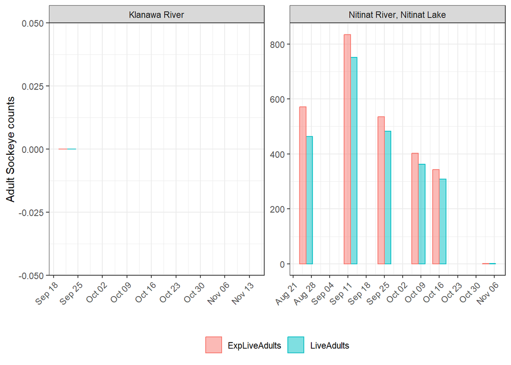

Figure: Observed live Adult sockeye (blue) and the same counts expanded for % population and/or OE (pink).

## 2.2 Counts & environmentals

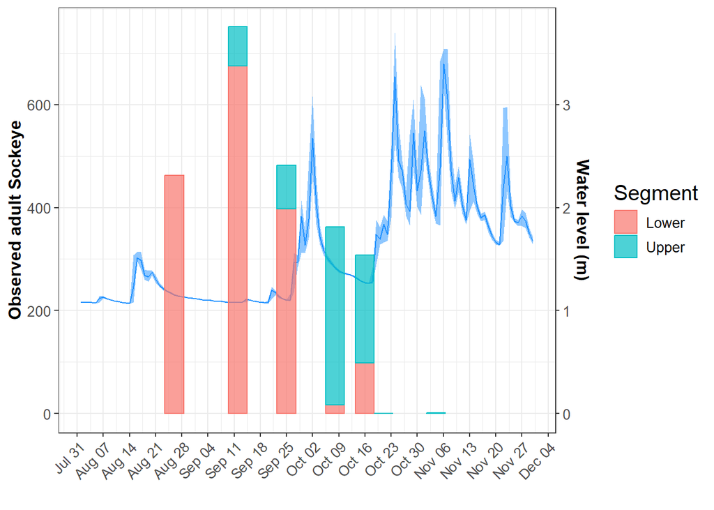

Figure: Sockeye counts (raw live adults), water levels (blue line)

## 2.3 Behaviour & carcasses

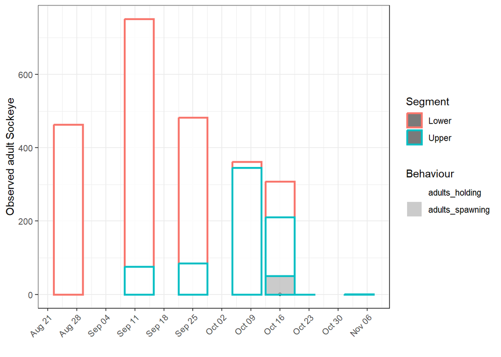

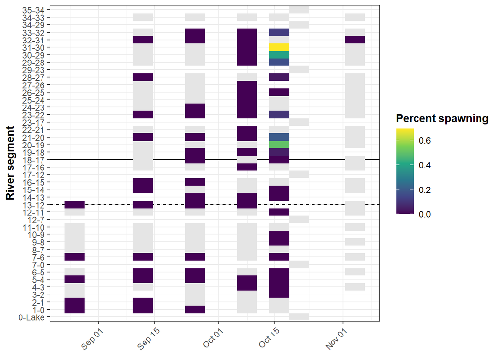

Figure: Sockeye spawning behaviour by reach break over each survey (snorkel and heli, if done). Solid black line denotes the differentiation between upper and lower Nitinat; dashed black line indicates where the hatchery is located along the river. Note heli and snorkel reach breaks are not the same. If any reach break is blank, it implies the surveyors missed the marker, and both reach counts were included in the one before. Counts with no Sockeye and/or no spawning Sockeye are indicated as gray (division by zero).

## 2.4 Snorkel & swim-in counts

There are no swim-ins for Nitinat sockeye as they are not enhanced.

## 2.5 Tributaries (River and Lake)

| date | NAME | ad_live | exp_ad_livve | dead_adults | jk_live | jk_dead |
| --- | --- | --- | --- | --- | --- | --- |
| 2025-04-30 | HOBITON CREEK | 0 | 0 | 0 | 0 | 0 |
| 2025-05-28 | HOBITON CREEK | 8 | 8 | 0 | 0 | 0 |
| 2025-06-17 | HOBITON CREEK | 2500 | 2632 | 0 | 0 | 0 |
| 2025-09-22 | KLANAWA RIVER | 0 | 0 | 0 | 0 | 0 |
| 2025-10-07 | HOBITON CREEK | 0 | 0 | 0 | 0 | 0 |
| 2025-10-10 | KLANAWA RIVER | 0 | 0 | 0 | 0 | 0 |
| 2025-10-21 | LITTLE NITINAT RIVER | 0 | 0 | 0 | 0 | 0 |
| 2025-10-29 | CAMPUS CREEK | 0 | 0 | 0 | 0 | 0 |
| 2025-11-12 | KLANAWA RIVER | 0 | 0 | 0 | 0 | 0 |

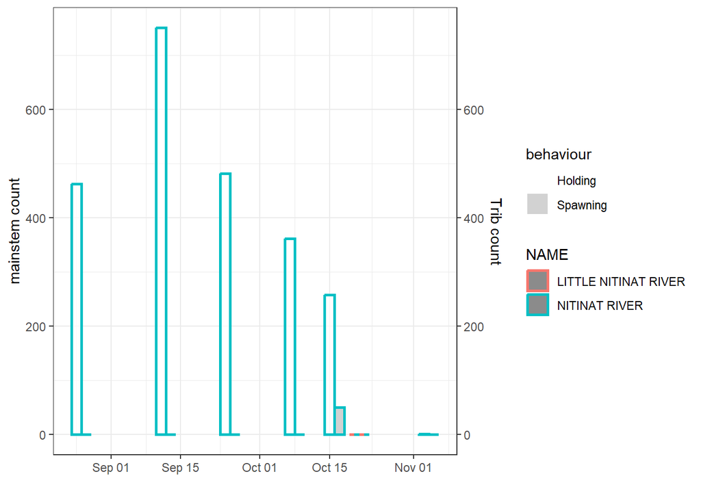

## 2.6 AUC assessments

The information below is meant to assist with determining if AUC is an appropriate method, and whether to include/exclude certain surveys. **Note that removals of surveys that are deemed irrelevant for a species/year has already been in the database prior to exporting the AUCresults file. This script does not really help with that unless you “restore to default” AUC data in the database and do some extra plotting yourself**

Table: AUC math for systems receiving AUC estimate in 2025

```
## # A tibble: 7 × 13
##   WatershedCode            Year ShortSpecies DateRange NoOfDays RawAdultFishDays
##   <chr>                   <dbl> <chr>        <chr>        <dbl>            <dbl>
## 1 930-071700-00000-00000…  2025 SK           2025/07/…       42           9723
## 2 930-071700-00000-00000…  2025 SK           2025/08/…       17          10319
## 3 930-071700-00000-00000…  2025 SK           2025/09/…       13           8014.
## 4 930-071700-00000-00000…  2025 SK           2025/09/…       13           5486
## 5 930-071700-00000-00000…  2025 SK           2025/10/…        8           2680
## 6 930-071700-00000-00000…  2025 SK           2025/10/…       19           2936.
## 7 930-071700-00000-00000…  2025 SK           2025/11/…       11              5.5
## # ℹ 7 more variables: RawJackFishDays <dbl>, ExpAdultFishDays <dbl>,
## #   ExpJackFishDays <dbl>, AREA <chr>, n <int>, SystemName <chr>, method <chr>
```

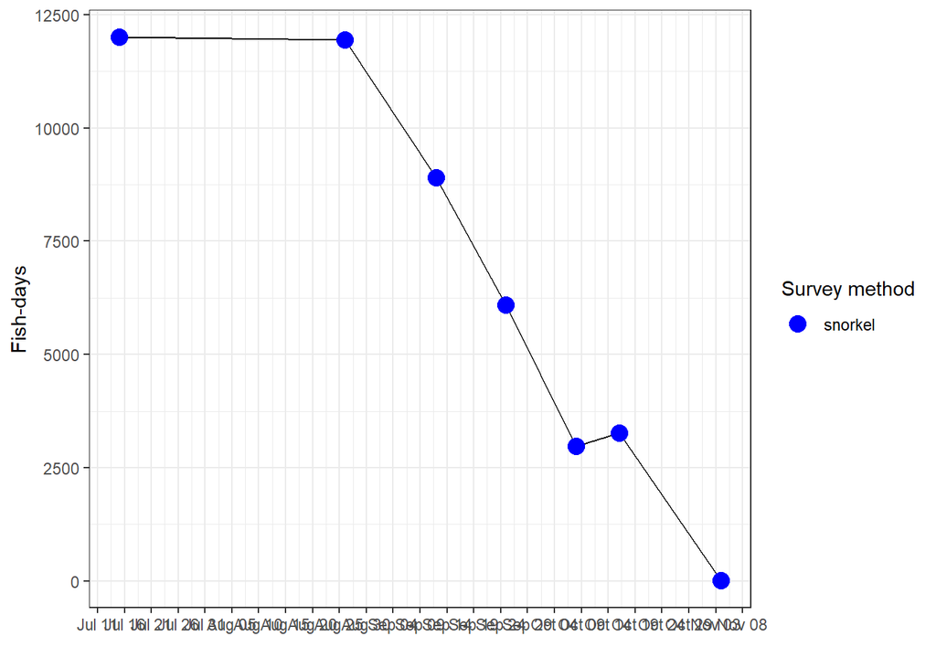

Figure: AUC curve for Nitinat mainstem Sockeye. Note in 2024 this had already excluded the heli survey, but in future would likely also include the flight for reference.

## 2.7 Area 21-22 preliminary escapement estimates

Table: Escapement estimates for each system.

| Year | SystemName | AREA | ShortSpecies | StartingZeroDate | EndingZeroDate | AdultShortResidenceTime | AdultMidResidenceTime_R | AdultLongResidenceTime | JackShortResidenceTime | JackMidResidenceTime_R | JackLongResidenceTime | AUCTotalDays | AdultExpAUCLowValue | AdultExpAUCMidValue_R | AdultExpAUCHighValue | JackExpAUCLowValue | JackExpAUCMidValue_R | JackExpAUCHighValue | AdultExpPLD | JackExpPLD | FinalAdultEstimate | AdultRemovalsReco | FinalJackEstimate | JackRemovalsReco | AdultRemovalsIncluded | JackRemovalsIncluded | EnumerationClass | IsFinal |
| --- | --- | --- | --- | --- | --- | --- | --- | --- | --- | --- | --- | --- | --- | --- | --- | --- | --- | --- | --- | --- | --- | --- | --- | --- | --- | --- | --- | --- |
| 2025 | Nitinat River, Nitinat Lake | 22 | SK | 2025-07-15 | 2025-11-15 | 30 | 35 | 40 | 30 | 35 | 40 | 123 | 1130 | 1292 | 1507 | 28 | 32 | 37 | 834 | 60 | 834 | 0 | 60 | 0 | FALSE | FALSE | 4 | FALSE |
|  | Klanawa River | 21 |  | 2025-09-01 | 2025-11-15 | 15 | 20 | 25 | 15 | 20 | 25 | 75 | 0 | 0 | 0 | 0 | 0 | 0 | 0 | 0 | 0 | 0 | 0 | 0 | FALSE | FALSE | 6 | FALSE |

### 2.7.1 Estimate decision:

Used PL+D as we didn’t quite get a good AUC curve this year. Expanded for vis and unsurveyed sections early on (e.g., upper) as early rainfall in ~Aug likely allowed upper river access early and potential for missing SK. Type-4 because still decent coverage.

## 2.8 2025 compared to historical run timing and abundance

Run timing information is not available for Nitinat Sockeye.

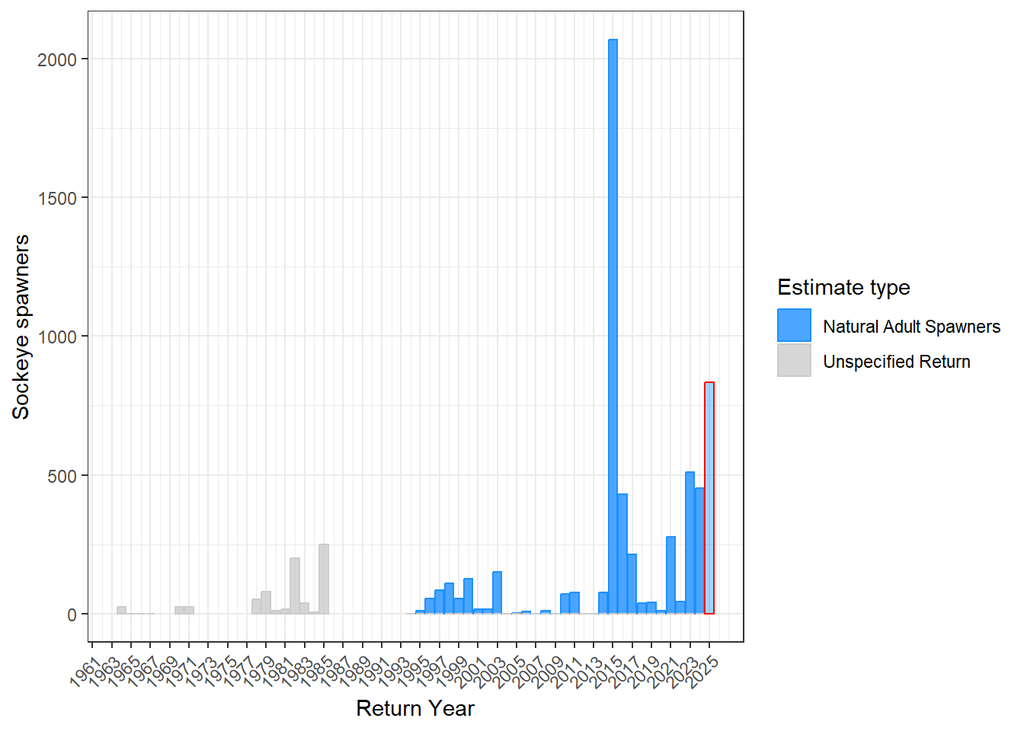

Figure: 2025 preliminary adult Sockeye escapement estimate (red outline) relative to historical adult (blue) and unspecified (gray) escapement estimates. Gaps indicate years without estimates.

# 3 **Coho**

## 3.1 Area 21-22 raw vs expanded counts

Counts are expanded for both % population surveyed and/or observer efficiency, depending on survey conditions.

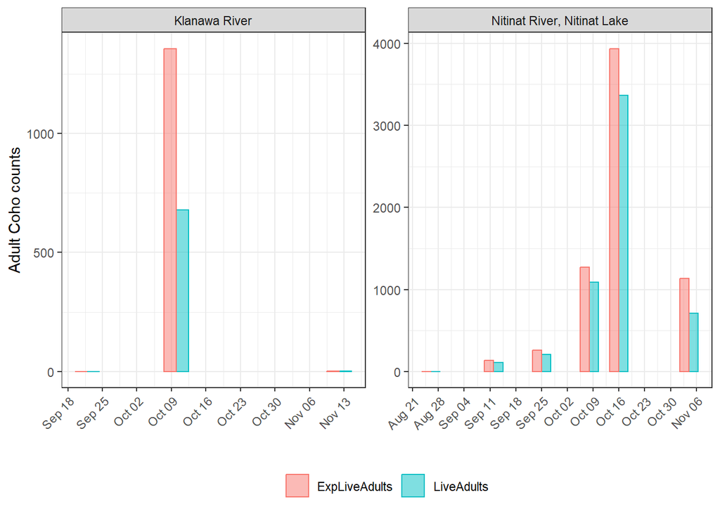

Figure: Observed Adult Coho (blue) and the same counts expanded for % population and/or OE (pink).

## 3.2 Counts & environmentals

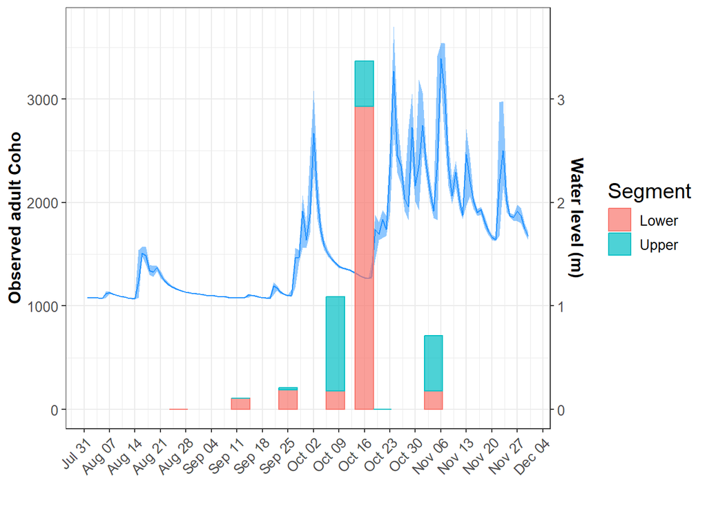

Figure: Observed adult Coho (bars) and water levels (blue line)

## 3.3 Behaviour & carcasses

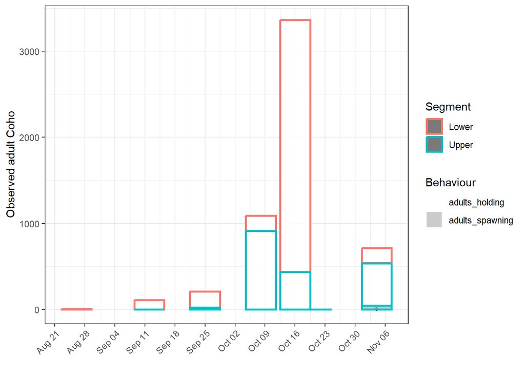

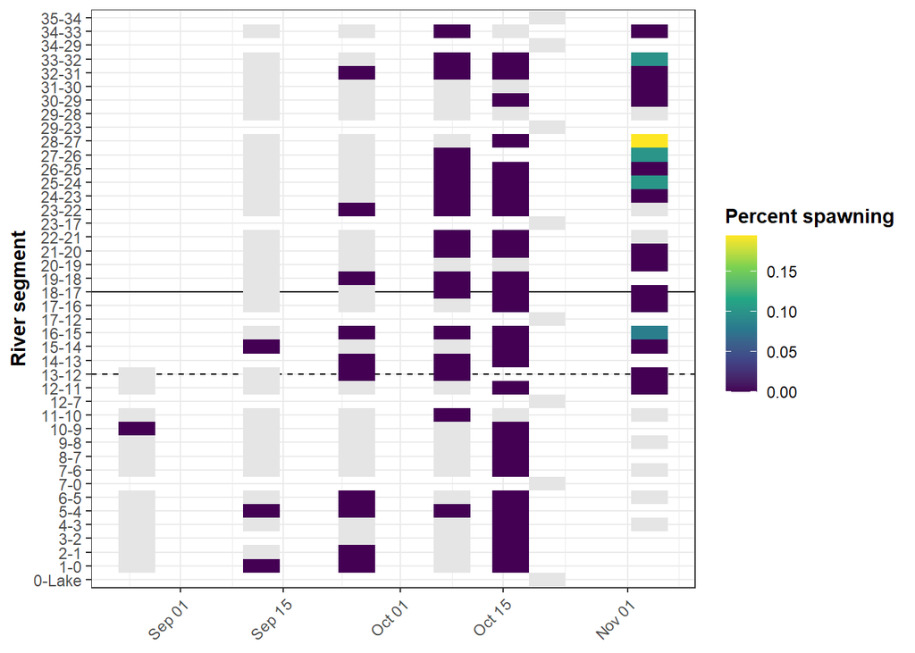

Figure: Coho spawning behaviour by reach break over each survey (snorkel and heli, if done). Solid black line denotes the differentiation between upper and lower Nitinat; dashed black line indicates where the hatchery is located along the river. Note heli and snorkel reach breaks are not the same. If any reach break is blank, it implies the surveyors missed the marker, and both reach counts were included in the one before. Counts with no Coho and/or no spawning Coho are indicated as gray (division by zero).

## 3.4 Snorkel, angling & swim-in counts

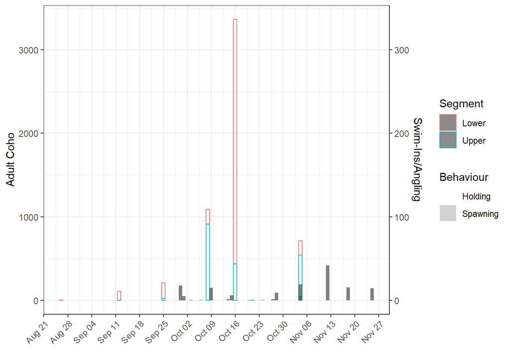

Total number of swim-ins this year is: 1314 adults and 134 jacks.

The total number collected from river beach seining is: 0, of which 0 were adults.

## 3.5 Mark rate

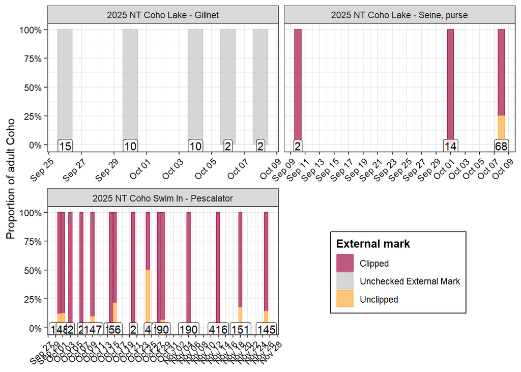

Figure: Coho mark rate by sample type. Gillnet catch represents catch by DFN, while purse seine catch represents NRH broodstock operations in the lake.

The overall mark rate of **ALL adult coho** pooled together was **89.1%**.

The mark rate of adult Coho **by gear type** was:

```
## # A tibble: 3 × 5
## # Groups:   capture_method [3]
##   capture_method                  total Unchecked External M…¹ Clipped Unclipped
##   <chr>                           <dbl>                  <dbl>   <dbl>     <dbl>
## 1 2025 NT Coho Lake - Gillnet        39                      1   NA        NA
## 2 2025 NT Coho Lake - Seine, pur…    70                     NA    0.76      0.24
## 3 2025 NT Coho Swim In - Pescala…  1314                     NA    0.92      0.08
## # ℹ abbreviated name: ¹`Unchecked External Mark`
```

### 3.5.1 Historical mark rate

```
## # A tibble: 33 × 6
## # Groups:   year, paste0(capture_type, " - ", capture_method) [18]
##     year paste0(capture_type, " - ", captu…¹ external_mark     n mark_rate total
##    <dbl> <chr>                               <chr>         <int>     <dbl> <int>
##  1  2020 Fishing Event - Seine, beach        Clipped          26      0.07   361
##  2  2020 Fishing Event - Seine, beach        Unchecked Ex…   140      0.39   361
##  3  2020 Fishing Event - Seine, beach        Unclipped       195      0.54   361
##  4  2020 Swim-In - Brailer                   Clipped         339      0.79   429
##  5  2020 Swim-In - Brailer                   Unclipped        90      0.21   429
##  6  2021 Fishing Event - Seine, beach        Clipped          27      0.16   169
##  7  2021 Fishing Event - Seine, beach        Unchecked Ex…   108      0.64   169
##  8  2021 Fishing Event - Seine, beach        Unclipped        34      0.2    169
##  9  2021 Swim-In - Brailer                   Clipped         585      0.98   598
## 10  2021 Swim-In - Brailer                   Unclipped        13      0.02   598
## # ℹ 23 more rows
## # ℹ abbreviated name: ¹`paste0(capture_type, " - ", capture_method)`
```

## 3.6 Tributaries (River and Lake)

| date | NAME | ad_live | exp_ad_livve | dead_adults | jk_live | jk_dead |
| --- | --- | --- | --- | --- | --- | --- |
| 2025-04-30 | HOBITON CREEK | 0 | 0 | 0 | 0 | 0 |
| 2025-05-28 | HOBITON CREEK | 0 | 0 | 0 | 0 | 0 |
| 2025-06-17 | HOBITON CREEK | 0 | 0 | 0 | 0 | 0 |
| 2025-09-22 | KLANAWA RIVER | 0 | 0 | 0 | 0 | 0 |
| 2025-10-07 | HOBITON CREEK | 0 | 0 | 0 | 0 | 0 |
| 2025-10-10 | KLANAWA RIVER | 678 | 678 | 0 | 0 | 0 |
| 2025-10-21 | LITTLE NITINAT RIVER | 0 | 0 | 0 | 0 | 0 |
| 2025-10-29 | CAMPUS CREEK | 3 | 4 | 0 | 0 | 0 |
| 2025-11-12 | KLANAWA RIVER | 1 | 1 | 0 | 0 | 0 |

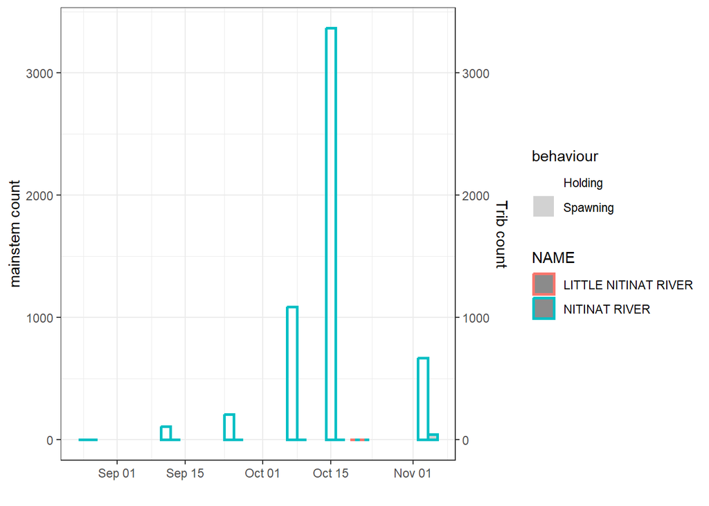

## 3.7 AUC assessments

The information below is meant to assist with determining if AUC is an appropriate method, and whether to include/exclude certain surveys.

Table: AUC math for systems receiving AUC estimate in 2025

```
## # A tibble: 7 × 13
##   WatershedCode            Year ShortSpecies DateRange NoOfDays RawAdultFishDays
##   <chr>                   <dbl> <chr>        <chr>        <dbl>            <dbl>
## 1 930-071700-00000-00000…  2025 CO           2025/08/…       11              5.5
## 2 930-071700-00000-00000…  2025 CO           2025/08/…       17            935
## 3 930-071700-00000-00000…  2025 CO           2025/09/…       13           2067
## 4 930-071700-00000-00000…  2025 CO           2025/09/…       13           8437
## 5 930-071700-00000-00000…  2025 CO           2025/10/…        8          17816
## 6 930-071700-00000-00000…  2025 CO           2025/10/…       19          38741
## 7 930-071700-00000-00000…  2025 CO           2025/11/…       57          20320.
## # ℹ 7 more variables: RawJackFishDays <dbl>, ExpAdultFishDays <dbl>,
## #   ExpJackFishDays <dbl>, AREA <chr>, n <int>, SystemName <chr>, method <chr>
```

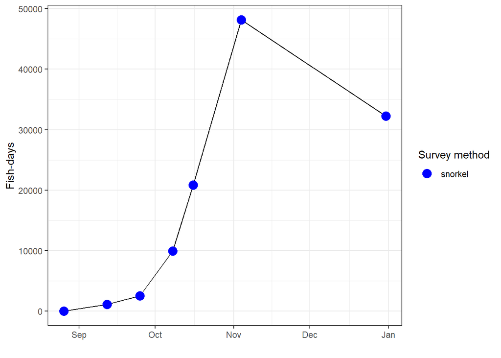

Figure: AUC curve for Nitinat mainstem Coho. Note in 2023 this had already excluded the heli survey, but in future would likely also include the flight for reference.

## 3.8 Area 21-22 preliminary escapement estimates (AUC/PL+D)

| Year | SystemName | AREA | ShortSpecies | StartingZeroDate | EndingZeroDate | AdultShortResidenceTime | AdultMidResidenceTime_R | AdultLongResidenceTime | JackShortResidenceTime | JackMidResidenceTime_R | JackLongResidenceTime | AUCTotalDays | AdultExpAUCLowValue | AdultExpAUCMidValue_R | AdultExpAUCHighValue | JackExpAUCLowValue | JackExpAUCMidValue_R | JackExpAUCHighValue | AdultExpPLD | JackExpPLD | FinalAdultEstimate | AdultRemovalsReco | FinalJackEstimate | JackRemovalsReco | AdultRemovalsIncluded | JackRemovalsIncluded | EnumerationClass | IsFinal |
| --- | --- | --- | --- | --- | --- | --- | --- | --- | --- | --- | --- | --- | --- | --- | --- | --- | --- | --- | --- | --- | --- | --- | --- | --- | --- | --- | --- | --- |
| 2025 | Nitinat River, Nitinat Lake | 22 | CO | 2025-08-20 | 2025-12-31 | 25 | 27.5 | 30 | 25 | 27.5 | 30 | 133 | 3831 | 4179 | 4597 | 528 | 576 | 634 | 3936 | 515 | 2865 | 1314 | 442 | 134 | TRUE | TRUE | 0 | FALSE |
|  | Klanawa River | 21 |  | 2025-09-01 | 2025-11-15 | 15 | 20.0 | 25 | 15 | 20.0 | 25 | 75 | 1384 | 1730 | 2307 | 0 | 0 | 0 | 1356 | 0 | 1356 | 0 | 0 | 0 | FALSE | FALSE | 6 | FALSE |

## 3.9 2025 compared to historical run timing and abundance

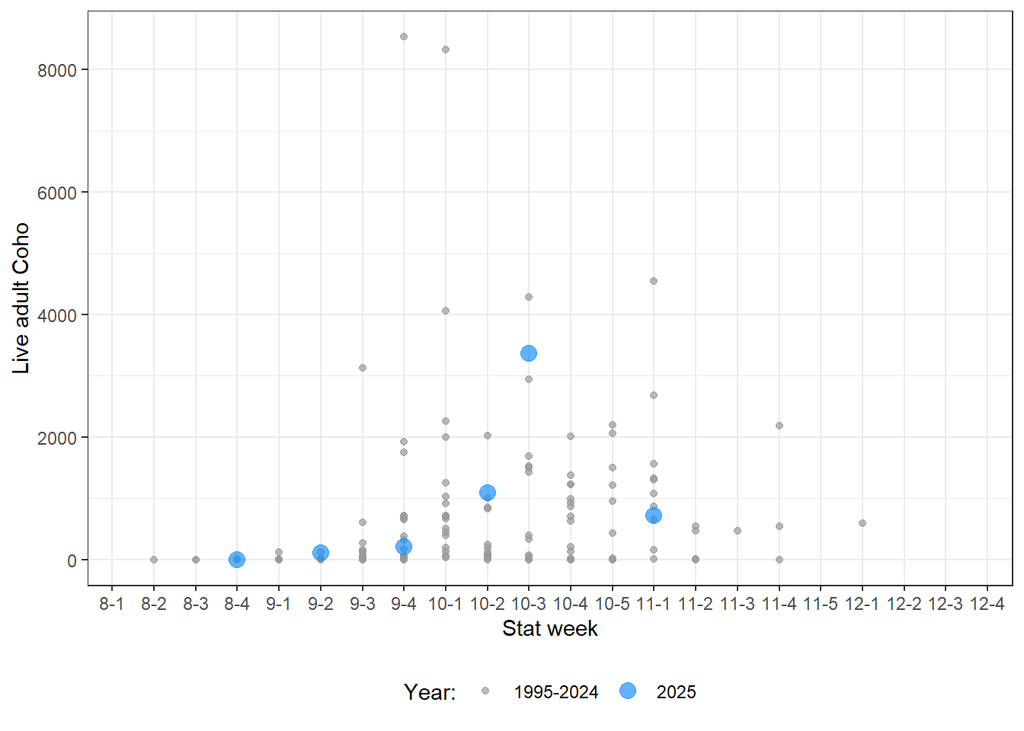

Figure: Raw swim counts (blue) from this year compared to historical raw swim counts. Stat weeks indicate the month (8=August, 12=December) and week of momth (1=first week, 2=2nd week, etc.), e.g., 81=First week of August, 91=First week of September, etc.

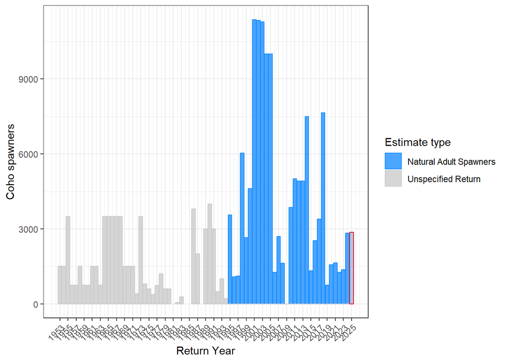

Figure: 2025 preliminary adult Coho escapement estimate (red outline) relative to historical adult (blue) and unspecified (gray) escapement estimates. Gaps indicate years without estimates.

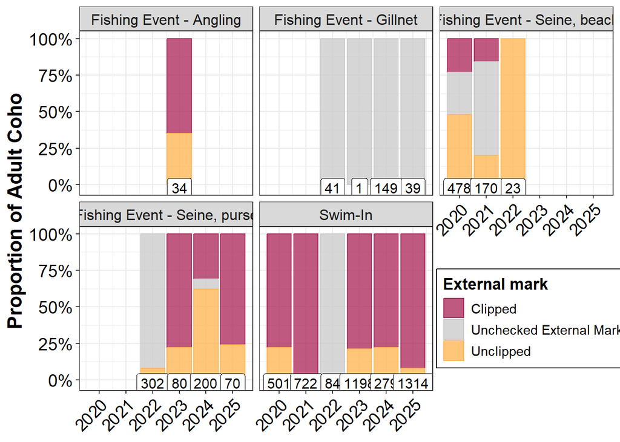

Figure: Mark rate of Nitinat Coho. Data from Adult Management EPRO.

# 4 **Chum**

## 4.1 Area 21-22 raw vs expanded counts

Counts are expanded for both % population surveyed and/or observer efficiency, depending on survey conditions.

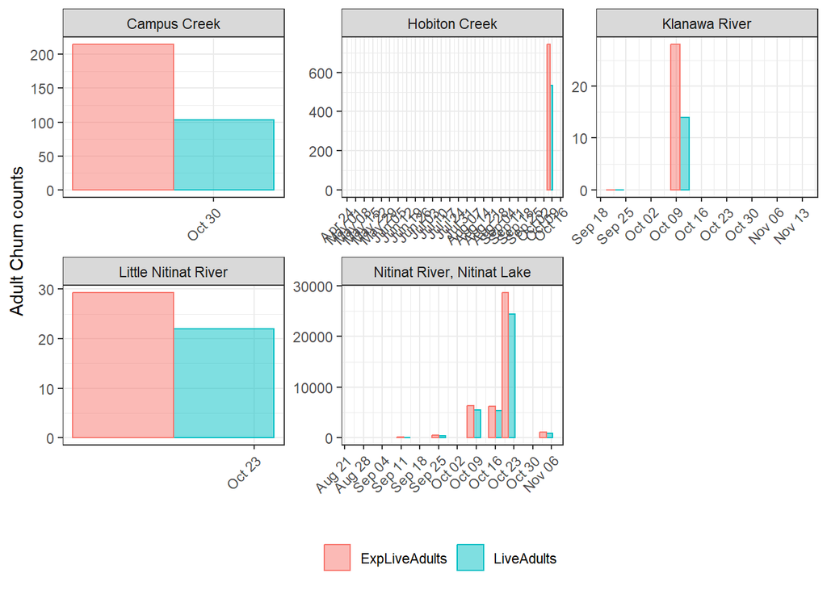

Figure: Observed Adult Chum (blue) and the same counts expanded for % population and/or OE (pink).

## 4.2 Counts & environmentals

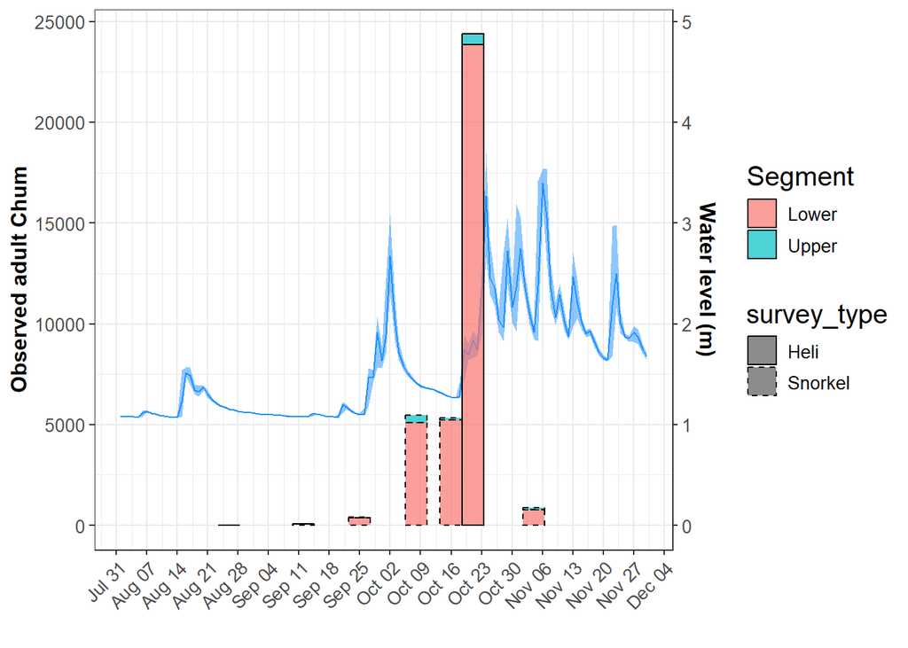

Figure: Chum counts (raw live adults), water levels (blue line)

## 4.3 Behaviour & carcasses

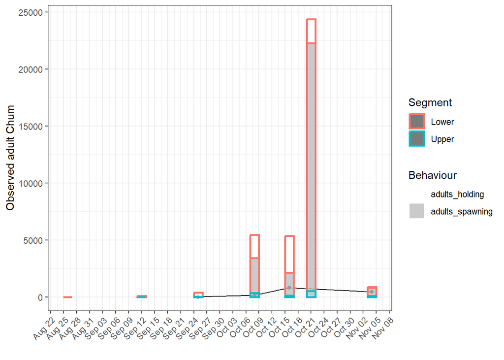

Figure: Expanded live adult Chum (bars) and carcasses (black line). Bar fill indicates behaviour (spawning=gray, holding=white), bar outline indicates river segment (upper=blue, lower=pink)

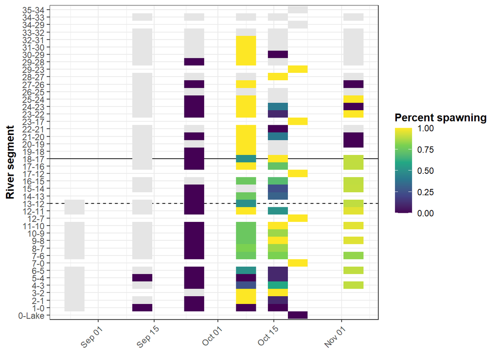

Figure: Chum spawning behaviour by reach break over each survey (snorkel and heli, if done). Solid black line denotes the differentiation between upper and lower Nitinat; dashed black line indicates where the hatchery is located along the river. Note heli and snorkel reach breaks are not the same. If any reach break is blank, it implies the surveyors missed the marker, and both reach counts were included in the one before. Counts with no Chum and/or no spawning Chum are indicated as gray (division by zero).

## 4.4 Snorkel & swim-in counts

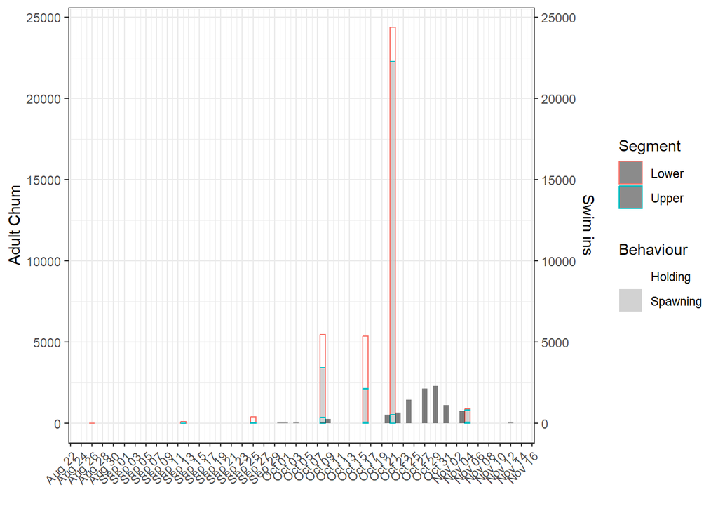

Figure: Expanded Chum counts (large bars) and swim-ins (narrow black bars). Adult bar fill colours indicate behaviour (spawning=gray, holding=white), bar line colour indicates river segment (lower=pink, upper=blue).

Total number of swim-ins this year is: 9116 adults.

## 4.5 Tributaries (River and Lake)

| date | NAME | ad_live | exp_ad_livve | dead_adults | jk_live | jk_dead |
| --- | --- | --- | --- | --- | --- | --- |
| 2025-04-30 | HOBITON CREEK | 0 | 0 | 0 | 0 | 0 |
| 2025-05-28 | HOBITON CREEK | 0 | 0 | 0 | 0 | 0 |
| 2025-06-17 | HOBITON CREEK | 0 | 0 | 0 | 0 | 0 |
| 2025-09-22 | KLANAWA RIVER | 0 | 0 | 0 | 0 | 0 |
| 2025-10-07 | HOBITON CREEK | 535 | 606 | 0 | 0 | 0 |
| 2025-10-10 | KLANAWA RIVER | 14 | 14 | 0 | 0 | 0 |
| 2025-10-21 | LITTLE NITINAT RIVER | 22 | 22 | 0 | 0 | 0 |
| 2025-10-29 | CAMPUS CREEK | 103 | 129 | 19 | 0 | 0 |
| 2025-11-12 | KLANAWA RIVER | 0 | 0 | 0 | 0 | 0 |

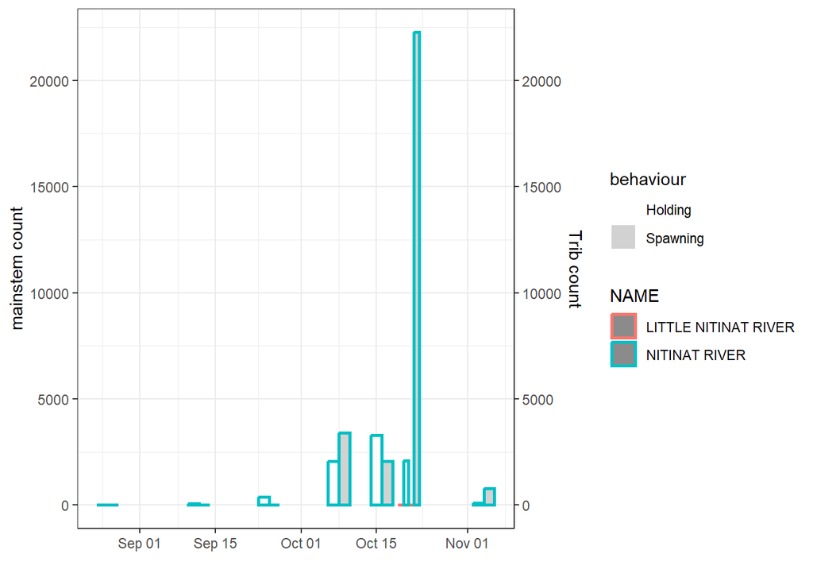

## 4.6 AUC assessments

The information below is meant to assist with determining if AUC is an appropriate method, and whether to include/exclude certain surveys.

Table: AUC math for systems receiving AUC estimate in 2025

```
## # A tibble: 10 × 13
##    WatershedCode           Year ShortSpecies DateRange NoOfDays RawAdultFishDays
##    <chr>                  <dbl> <chr>        <chr>        <dbl>            <dbl>
##  1 930-071700-00000-0000…  2025 CM           2025/08/…        1               0
##  2 930-071700-00000-0000…  2025 CM           2025/08/…       17             672.
##  3 930-071700-00000-0000…  2025 CM           2025/09/…       13            3055
##  4 930-071700-00000-0000…  2025 CM           2025/09/…       13           38044.
##  5 930-071700-00000-0000…  2025 CM           2025/10/…        8           43184
##  6 930-071700-00000-0000…  2025 CM           2025/10/…        5           74260
##  7 930-071700-00000-0000…  2025 CM           2025/10/…       14          176624
##  8 930-071700-00000-0000…  2025 CM           2025/11/…       26           11206
##  9 930-071700-37600-0000…  2025 CM           2025/09/…       50             550
## 10 930-071700-37600-0000…  2025 CM           2025/10/…       25             275
## # ℹ 7 more variables: RawJackFishDays <dbl>, ExpAdultFishDays <dbl>,
## #   ExpJackFishDays <dbl>, AREA <chr>, n <int>, SystemName <chr>, method <chr>
```

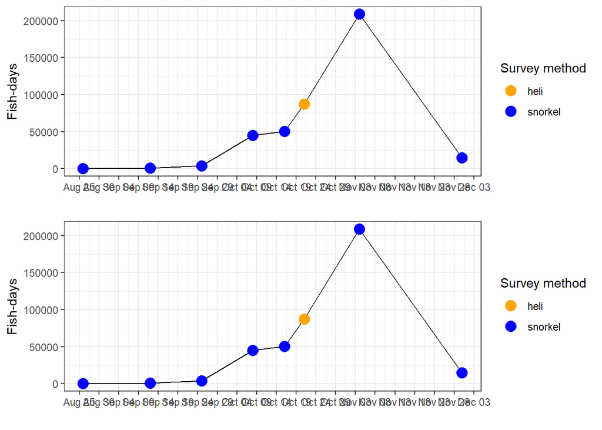

Figure: AUC curve for Nitinat mainstem Chum.

## 4.7 Area 21-22 preliminary escapement estimates (AUC)

Table: Escapement estimates for each system.

| Year | SystemName | AREA | ShortSpecies | StartingZeroDate | EndingZeroDate | AdultShortResidenceTime | AdultMidResidenceTime_R | AdultLongResidenceTime | JackShortResidenceTime | JackMidResidenceTime_R | JackLongResidenceTime | AUCTotalDays | AdultExpAUCLowValue | AdultExpAUCMidValue_R | AdultExpAUCHighValue | JackExpAUCLowValue | JackExpAUCMidValue_R | JackExpAUCHighValue | AdultExpPLD | JackExpPLD | FinalAdultEstimate | AdultRemovalsReco | FinalJackEstimate | JackRemovalsReco | AdultRemovalsIncluded | JackRemovalsIncluded | EnumerationClass | IsFinal |
| --- | --- | --- | --- | --- | --- | --- | --- | --- | --- | --- | --- | --- | --- | --- | --- | --- | --- | --- | --- | --- | --- | --- | --- | --- | --- | --- | --- | --- |
| 2025 | Nitinat River, Nitinat Lake | 22 | CM | 2025-09-01 | 2025-11-30 | 8 | 9 | 10 | 8 | 9 | 10 | 97 | 41052 | 45613 | 51315 | 0 | 0 | 0 | 28671 | 0 | 51315 | 9116 | 0 | 0 | FALSE | FALSE | 3 | FALSE |
|  | Hobiton Creek |  |  | 2025-09-01 | 2025-11-15 | 15 | 20 | 25 | 15 | 20 | 25 | 200 | 580 | 724 | 966 | 0 | 0 | 0 | 742 | 0 | 0 | 0 | 0 | 0 | FALSE | FALSE | 0 | FALSE |
|  | Campus Creek |  |  | 2025-09-01 | 2025-11-15 | 15 | 20 | 25 | 15 | 20 | 25 | 75 | 322 | 402 | 536 | 0 | 0 | 0 | 247 | 0 | 0 | 0 | 0 | 0 | FALSE | FALSE | 0 | FALSE |
|  | Little Nitinat River |  |  | 2025-09-01 | 2025-11-15 | 15 | 20 | 25 | 15 | 20 | 25 | 75 | 44 | 55 | 73 | 0 | 0 | 0 | 29 | 0 | 29 | 0 | 0 | 0 | FALSE | FALSE | 0 | FALSE |
|  | Klanawa River | 21 |  | 2025-09-01 | 2025-11-15 | 15 | 20 | 25 | 15 | 20 | 25 | 75 | 10 | 13 | 17 | 0 | 0 | 0 | 28 | 0 | 28 | 0 | 0 | 0 | FALSE | FALSE | 6 | FALSE |

### 4.7.1 Estimate decision:

Assumed the following for broodstock operations: - Swim-ins mostly came in after the peak heli count on Oct 21. There were only ~2100 holding Chum counted on that flight, but 8,334 Chum swam into the hatchery. The flight noted that counting was often difficult at edges and in deep, dark pools, so it’s possible that fish holding in pools (not spawning) were missed. Therefore **the swim-ins should be in addition to the river escapement estimate**.

Chum arrival this year was quite late for Nitinat, which also tracks elsewhere on the island: Johnstone Strait test fishery saw a very late, large bump of Chum just days before the fishery was set to close. This is reflected in several of the figures above. Note in the behavioural figures, Chum arrived and were immediately fungus-y and spawning. In particular, there was a massive bump sometime between Oct 16 and 21st; when we flew Oct 21 those fish were already all entirely spawning, which implies a very short residence time. For this reason, we selected the expanded AUC estimate with the shorter survey life (8 days).

Note this year may be a low estimate due to two lake turnover events: September 17 and October 14. On the Sept 17th event, the hatchery lost ~3000 Chinook broodstock that were being held in the lake pens. There was speculation that fish in the lake may have been able to swim away and avoid the low oxygen conditions, while those stuck in the pens died. However, the extent of the die off from both events is unknown. Hatchery staff reported the lake smelled like rotten eggs on Oct 14 as well (presumably due to anoxic layer coming to surface). The early event would have impacted Chinook more, while the later event would have impacted Chum more (if there were impacts).

## 4.8 2025 compared to historical run timing

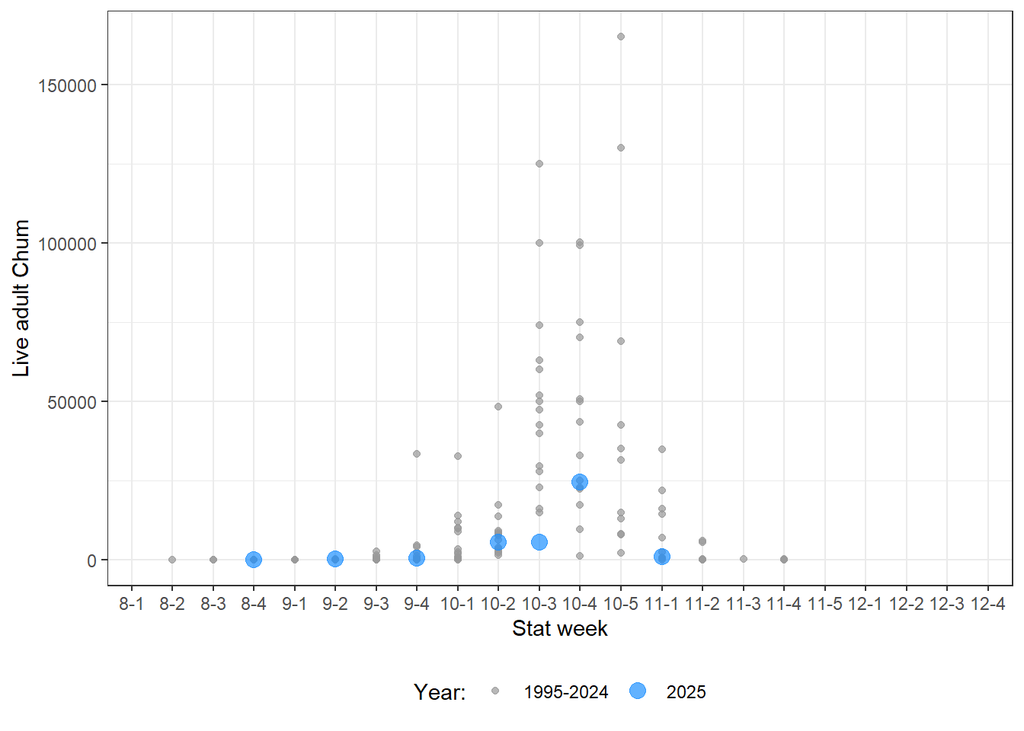

Figure: Raw swim counts (blue) from this year compared to historical raw swim counts. Stat weeks indicate the month (8=August, 12=December) and week of momth (1=first week, 2=2nd week, etc.), e.g., 81=First week of August, 91=First week of September, etc.

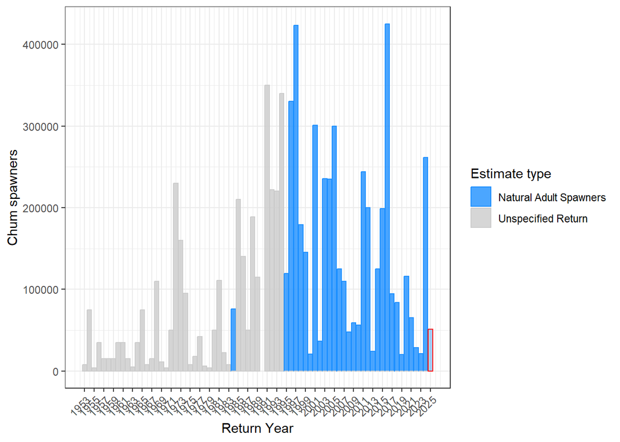

# 5 **Chinook**

## 5.1 Area 21-22 raw vs expanded counts

Counts are expanded for both % population surveyed and/or observer efficiency, depending on survey conditions.

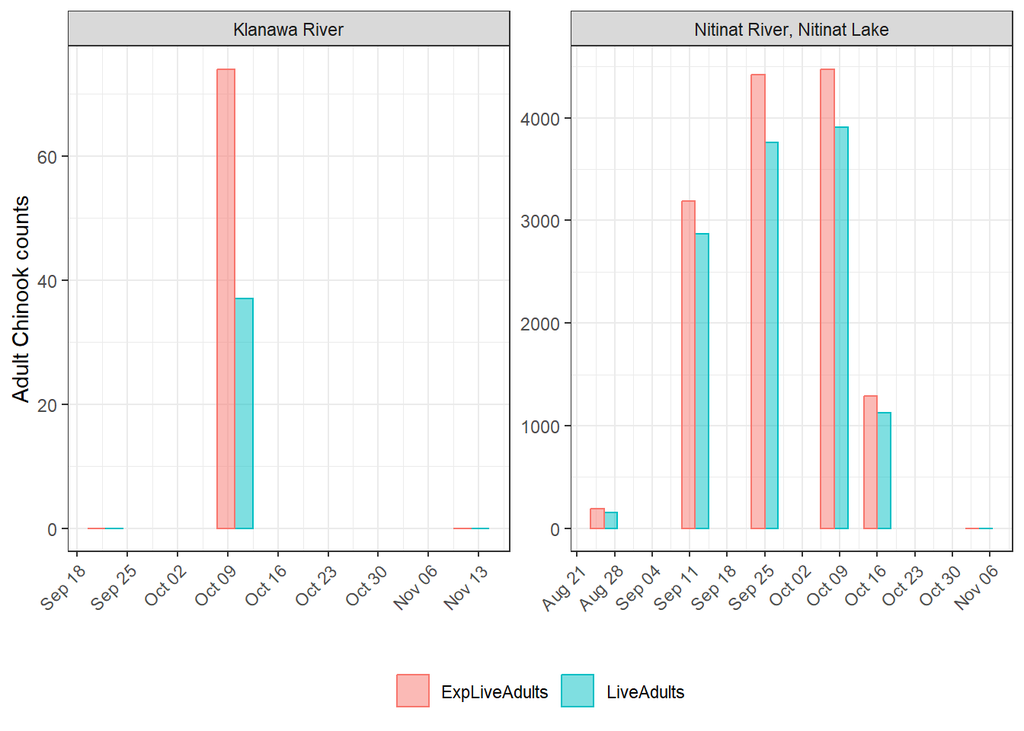

Figure: Observed Adult Chinook (blue) and the same counts expanded for % population and/or OE (pink).

## 5.2 Counts & environmentals

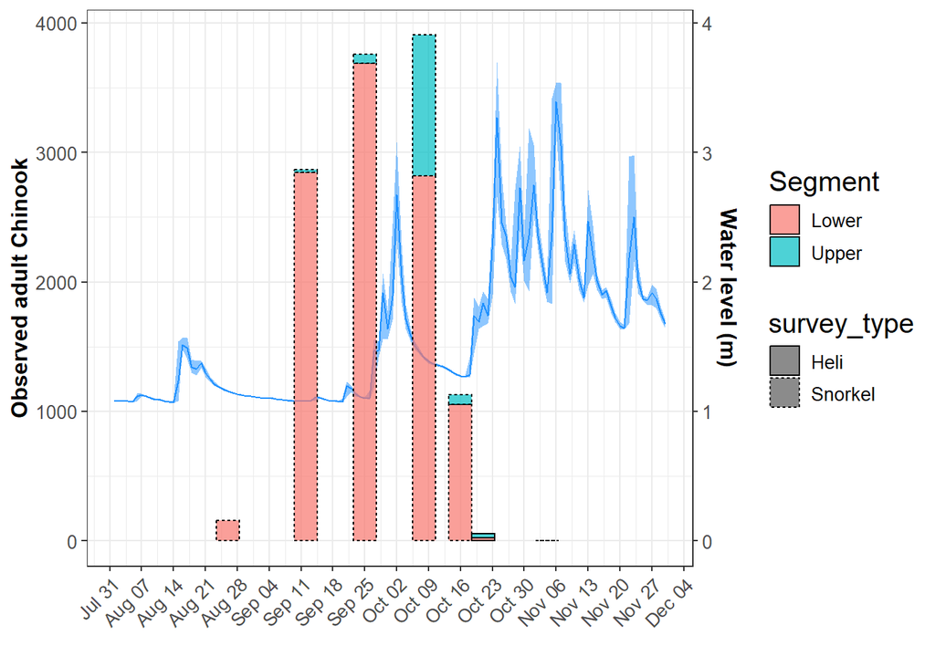

Figure: Chinook counts (raw live adults), water levels (blue line)

## 5.3 Behaviour & carcasses

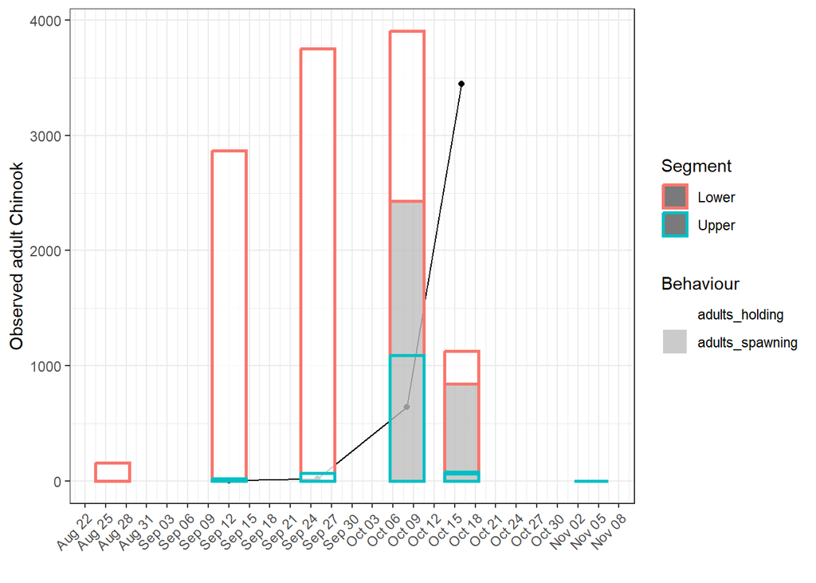

Figure: Expanded live adult Chinook (bars) and carcasses (black line). Bar fill indicates behaviour (spawning=gray, holding=white), bar outline indicates river segment (upper=blue, lower=pink).

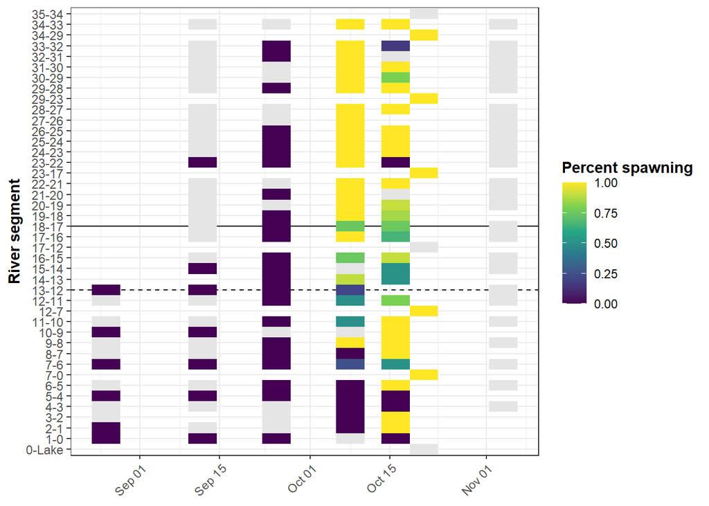

Figure: Chinook spawning behaviour by reach break over each survey (snorkel and heli, if done). Solid black line denotes the differentiation between upper and lower Nitinat; dashed black line indicates where the hatchery is located along the river. Note heli and snorkel reach breaks are not the same. If any reach break is blank, it implies the surveyors missed the marker, and both reach counts were included in the one before. Counts with no Chinook and/or no spawning Chinook are indicated as gray because % spawn can’t be calculated (division by zero).